# Analysis of Selected Libraries

David Jackson

9/27/2021

### Hypothess:

“A supposition or proposed explanation made on the basis of limited evidence as a starting point for further investigation.”

### What is the Null Hypothesis?

" The null hypothesis states that there is no relationship between two population parameters, i.e., an independent variable and a dependent variable. If the hypothesis shows a relationship between the two parameters, the outcome could be due to an experimental or sampling error. However, if the null hypothesis returns false, there is a relationship in the measured phenomenon." (https://corporatefinanceinstitute.com/)

### What is Our Null Hypothesis?

That there is no relationship between race (of the main charactors) and the purchasing habits of eighteen selected library branches.

### The p-value explained

The p-value is a number, calculated from a statistical test, that describes how likely you are to have found a particular set of observations if the null hypothesis were true.

P-values are used in hypothesis testing to help decide whether to reject the null hypothesis. The **smaller the p-value** , the more likely you are to **reject** the null hypothesis.

[output not shown]

## Analysis of Audio books by Race of Main Character

### Branch Library: bkctf

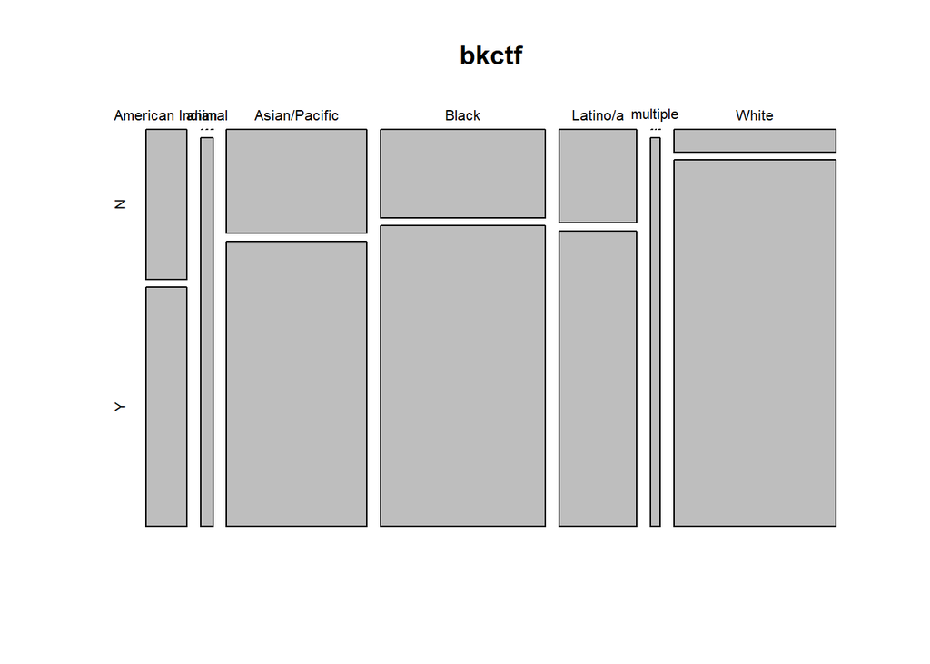

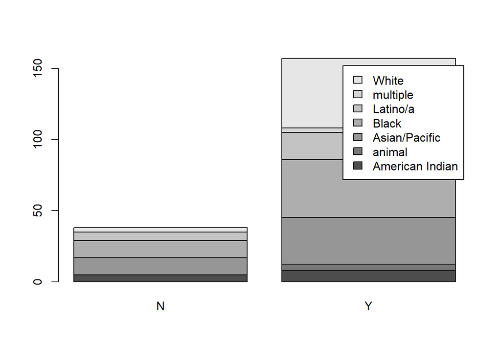

```
##
##  Pearson's Chi-squared test
##
## data:  bkctf
## X-squared = 13.053, df = 6, p-value = 0.0422
```

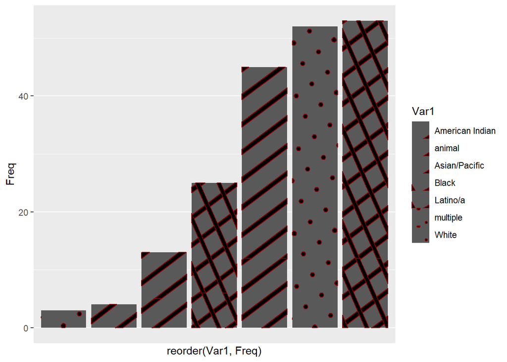

### Branch Library: bk_b

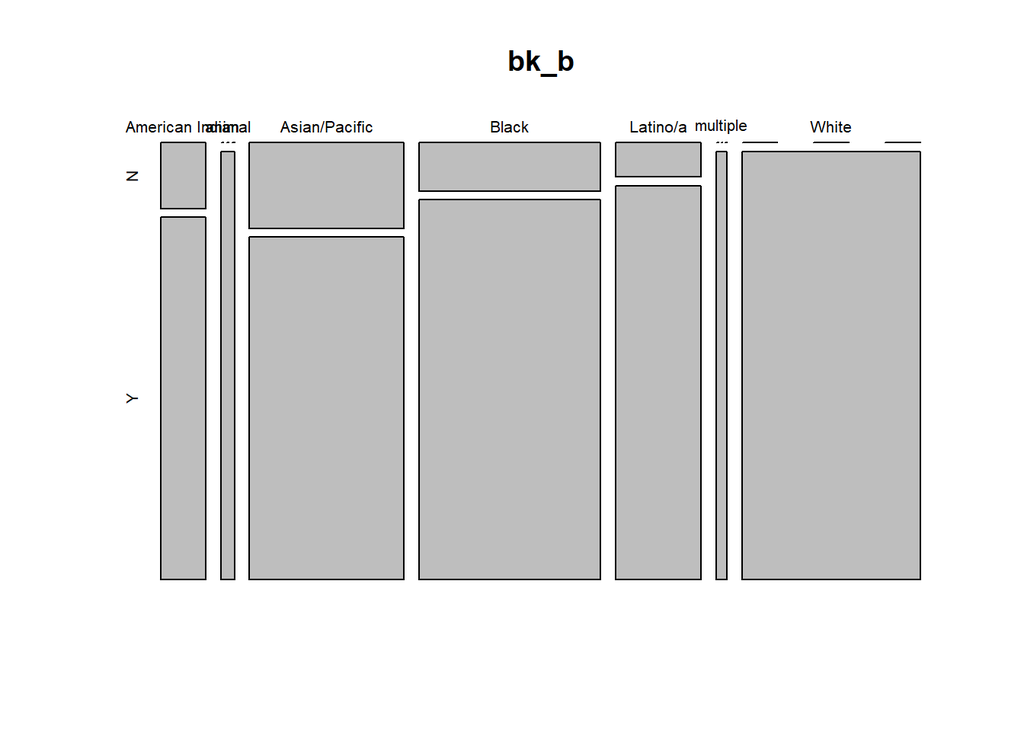

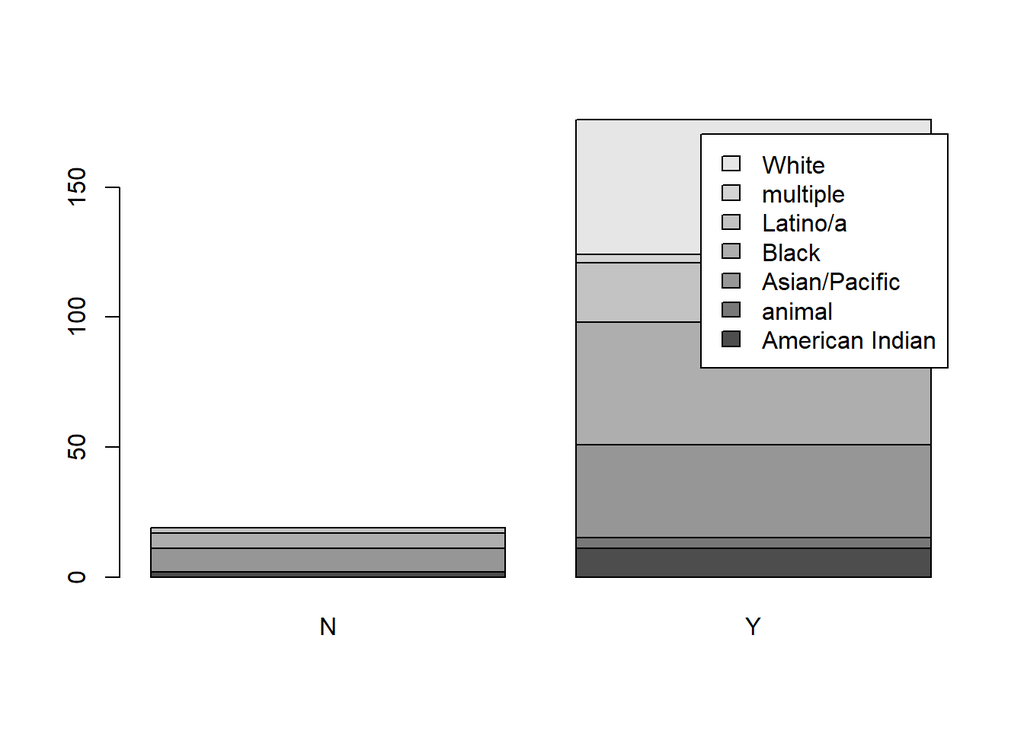

```
##
##  Pearson's Chi-squared test
##
## data:  bk_b
## X-squared = 12.459, df = 6, p-value = 0.05248
```

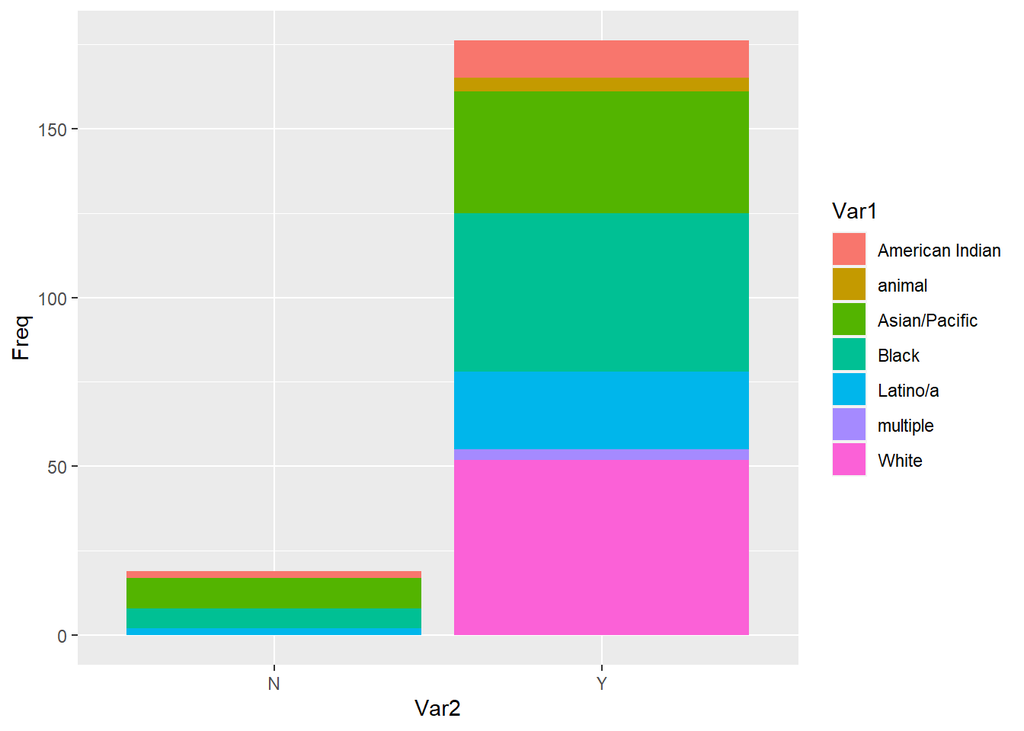

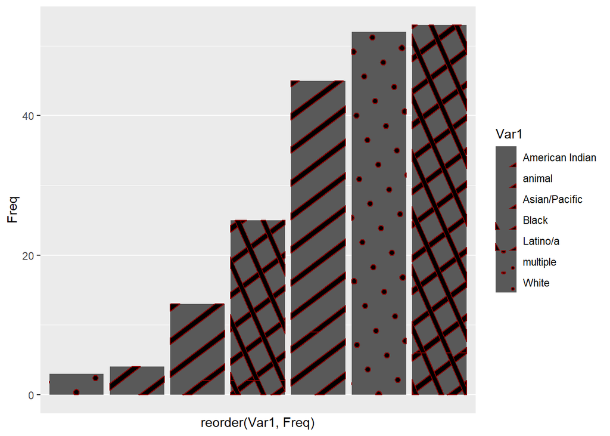

### Branch Library: dig_ctb

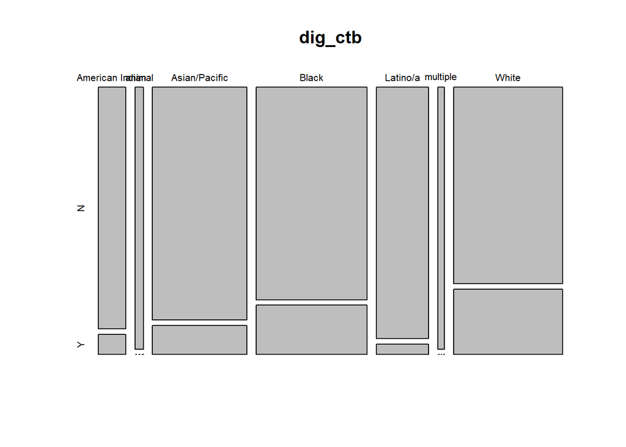

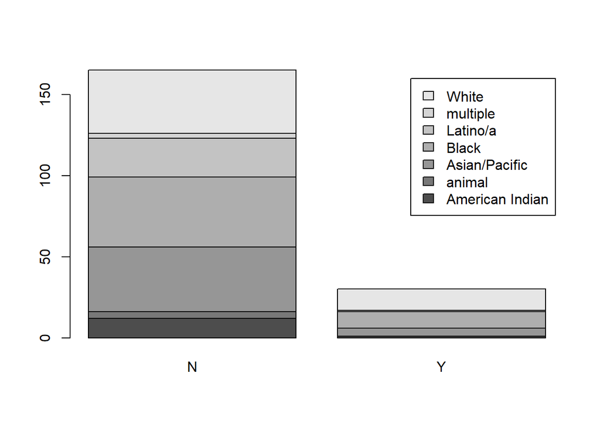

```
##
##  Pearson's Chi-squared test
##
## data:  dig_ctb
## X-squared = 9.1712, df = 6, p-value = 0.1642
```

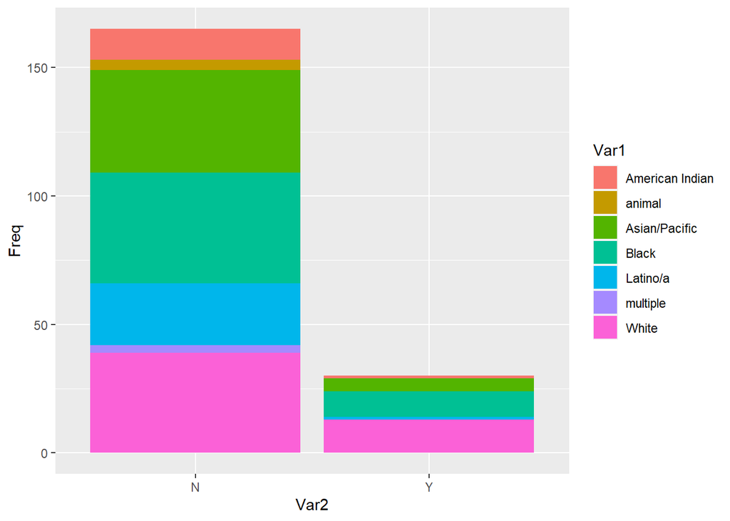

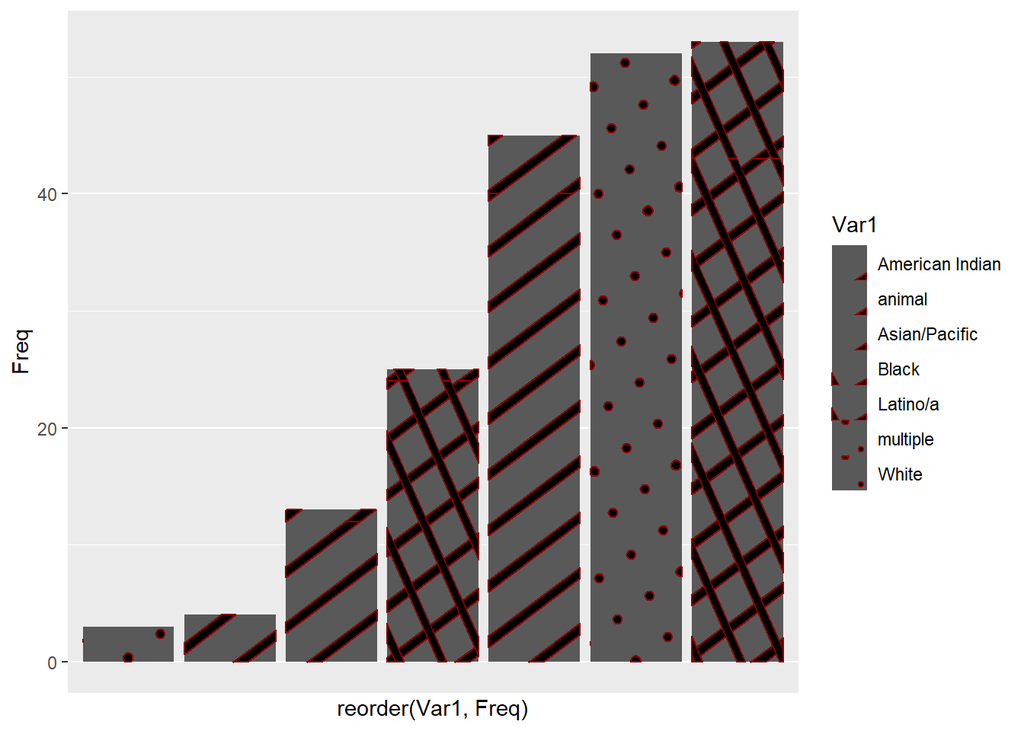

## Branches Where Null Hypothesis was Rejected (P < 0.04)

### Branch Library: bkcta

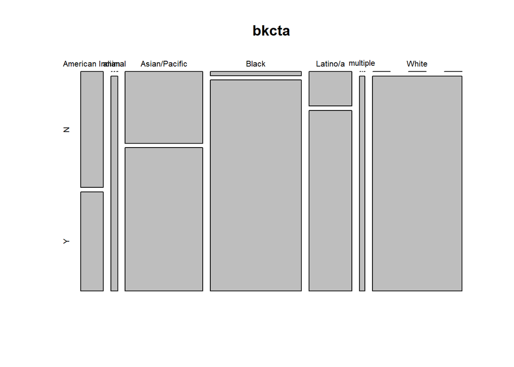

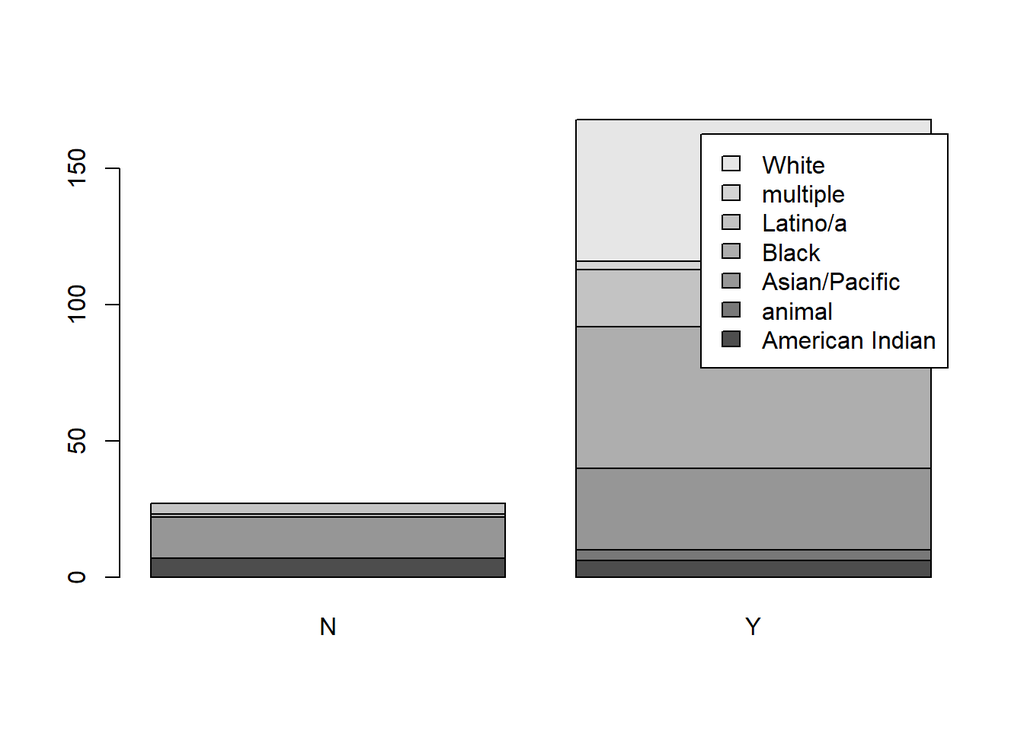

```
##
##  Pearson's Chi-squared test
##
## data:  bkcta
## X-squared = 47.696, df = 6, p-value = 1.359e-08
```

```
##
##   N   Y
##  27 168
```

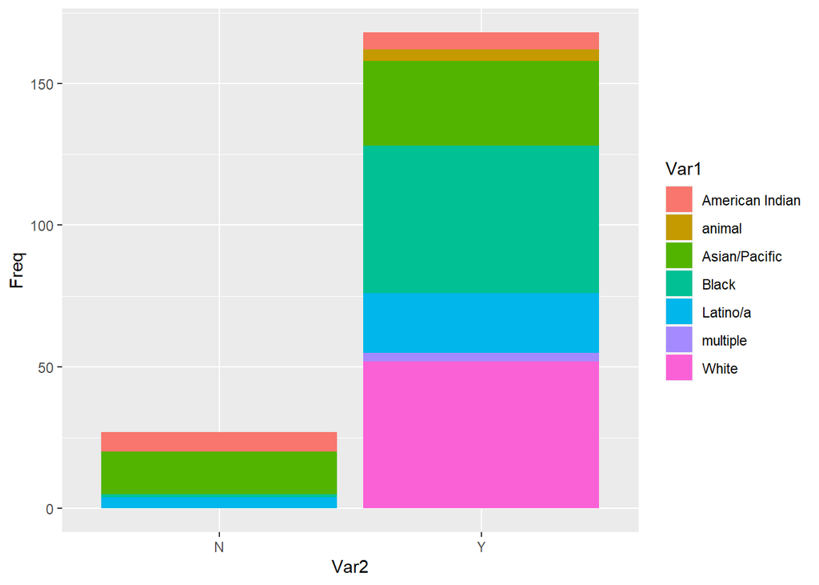

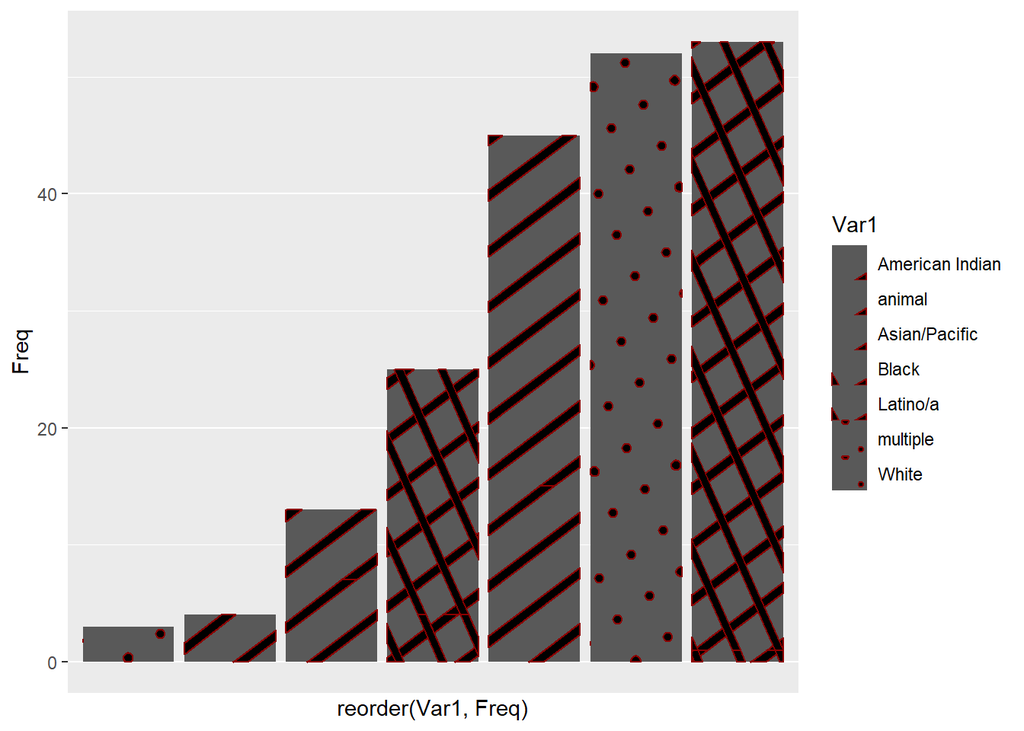

### Branch Library: cdcta

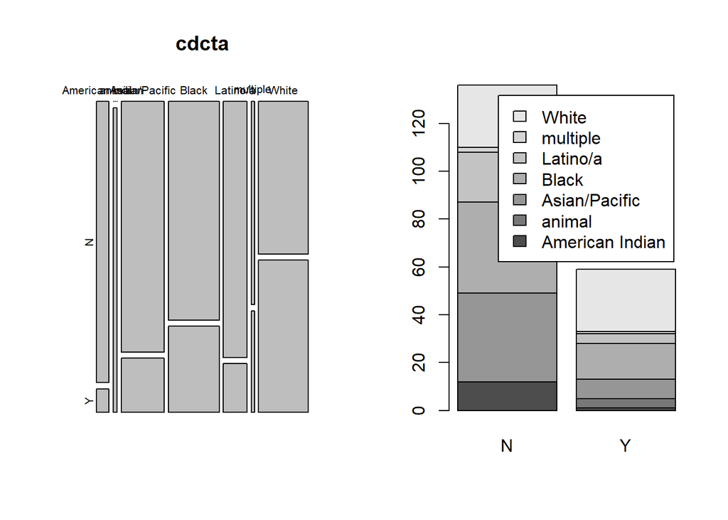

```
##
##  Pearson's Chi-squared test
##
## data:  cdcta
## X-squared = 27.801, df = 6, p-value = 0.0001024
```

[figure not shown]

### Branch Library: dig_cta

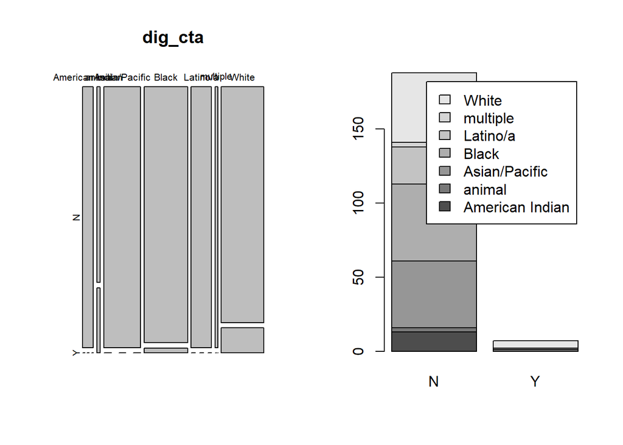

```
##
##  Pearson's Chi-squared test
##
## data:  dig_cta
## X-squared = 14.4, df = 6, p-value = 0.02548
```

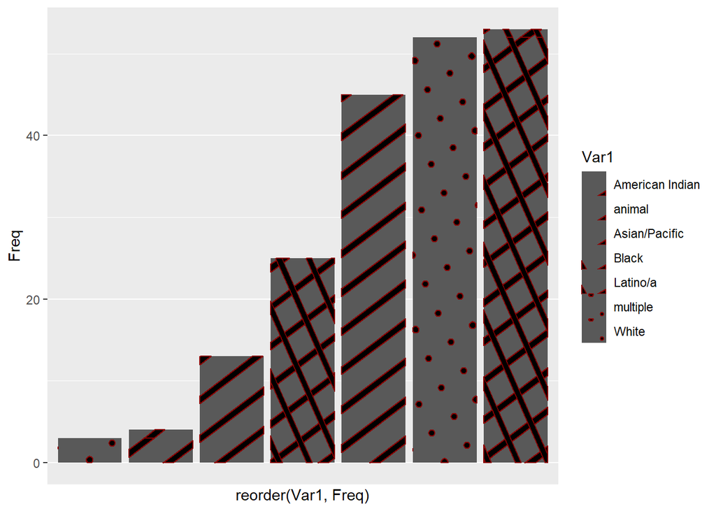

### Branch Library: cdctb

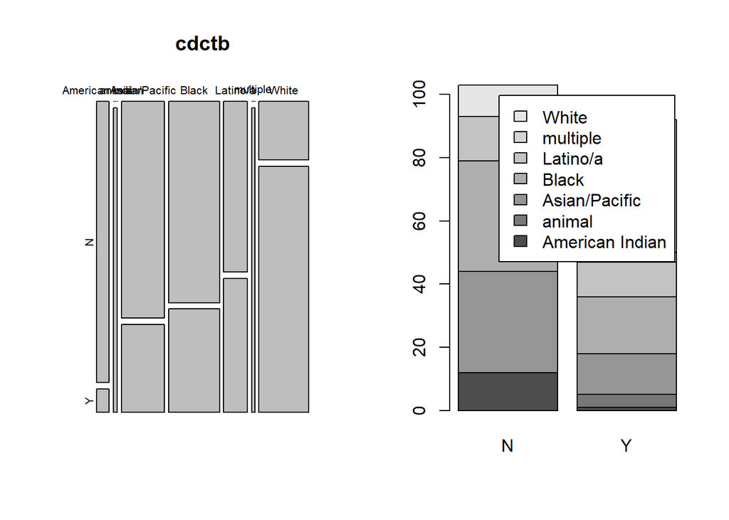

```
##
##  Pearson's Chi-squared test
##
## data:  cdctb
## X-squared = 49.372, df = 6, p-value = 6.282e-09
```

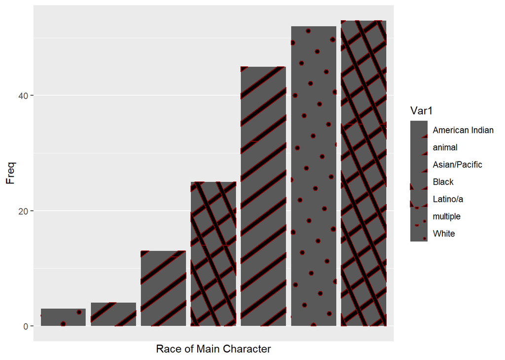

### Branch Library: bkctc

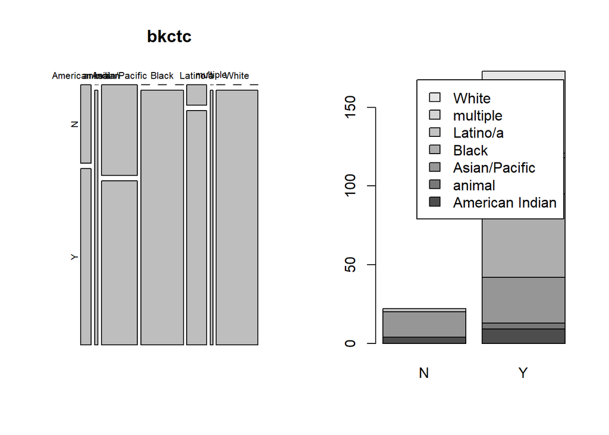

```
##
##  Pearson's Chi-squared test
##
## data:  bkctc
## X-squared = 45.934, df = 6, p-value = 3.052e-08
```

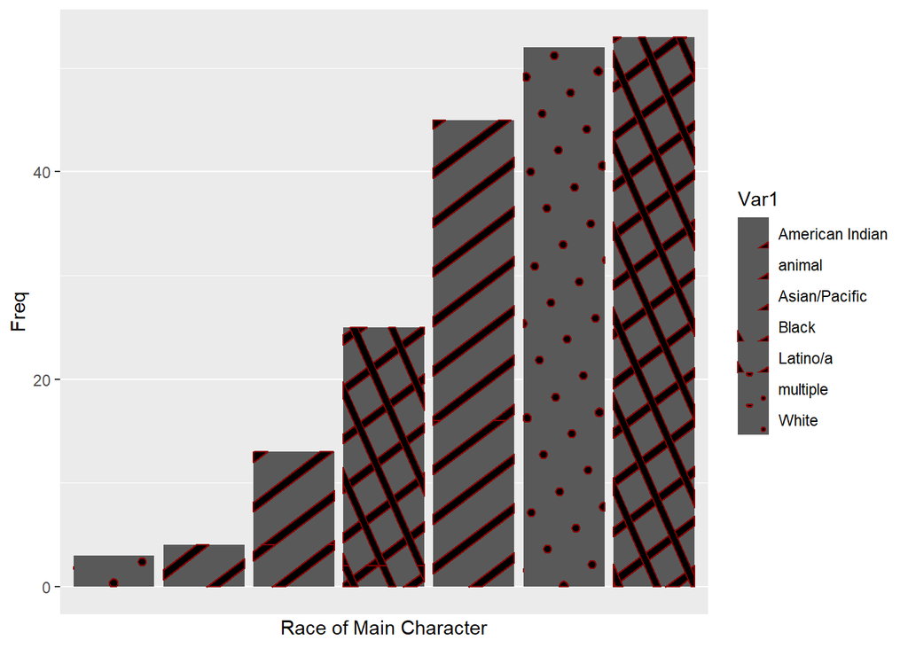

### Branch Library: cdctc

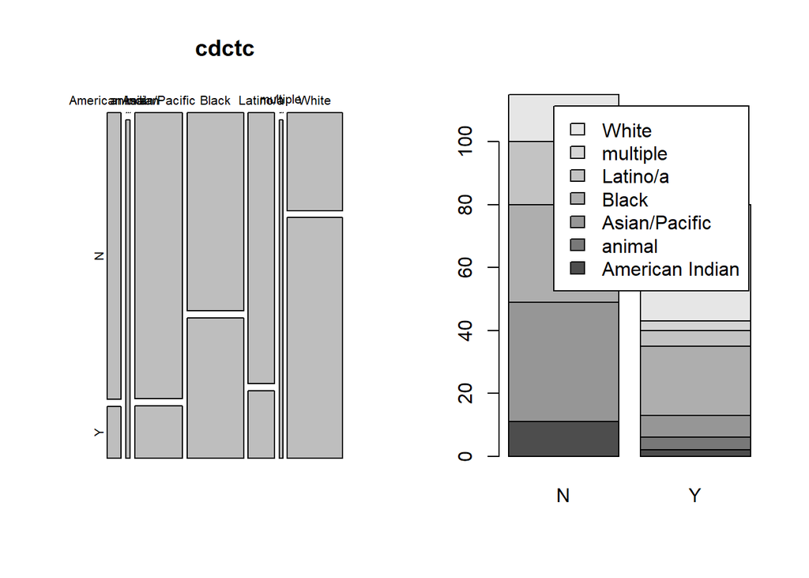

```
##
##  Pearson's Chi-squared test
##
## data:  cdctc
## X-squared = 49.743, df = 6, p-value = 5.294e-09
```

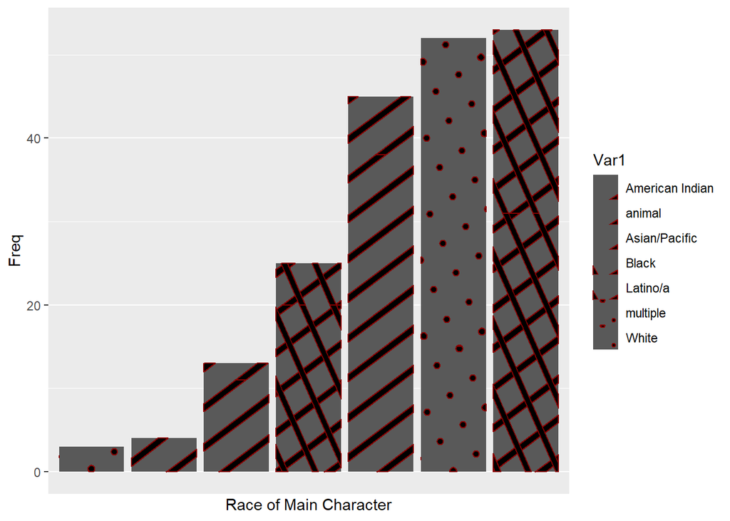

### Branch Library: dig_ctc

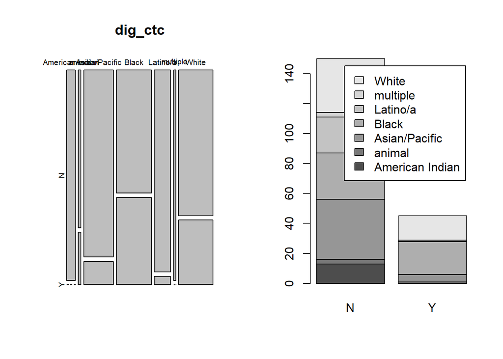

```
##
##  Pearson's Chi-squared test
##
## data:  dig_ctc
## X-squared = 25.441, df = 6, p-value = 0.0002829
```

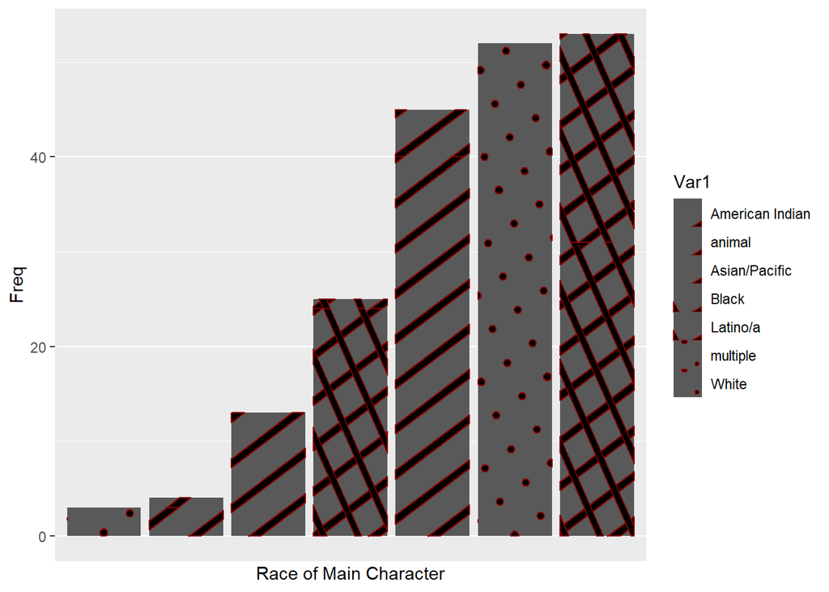

### Branch Library: bkctd

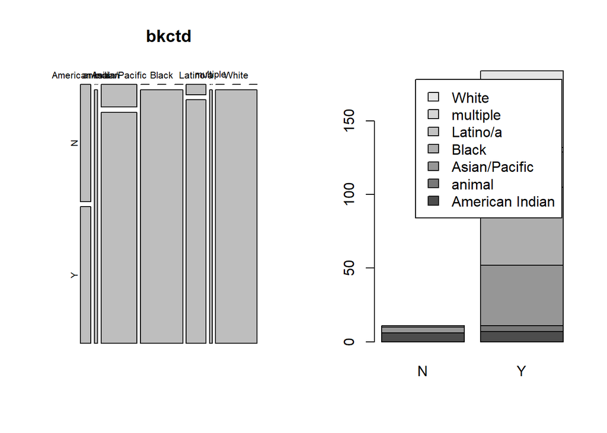

```
##
##  Pearson's Chi-squared test
##
## data:  bkctd
## X-squared = 47.799, df = 6, p-value = 1.296e-08
```

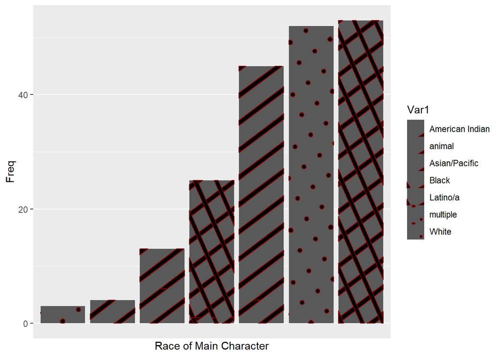

### Branch Library: cdctd

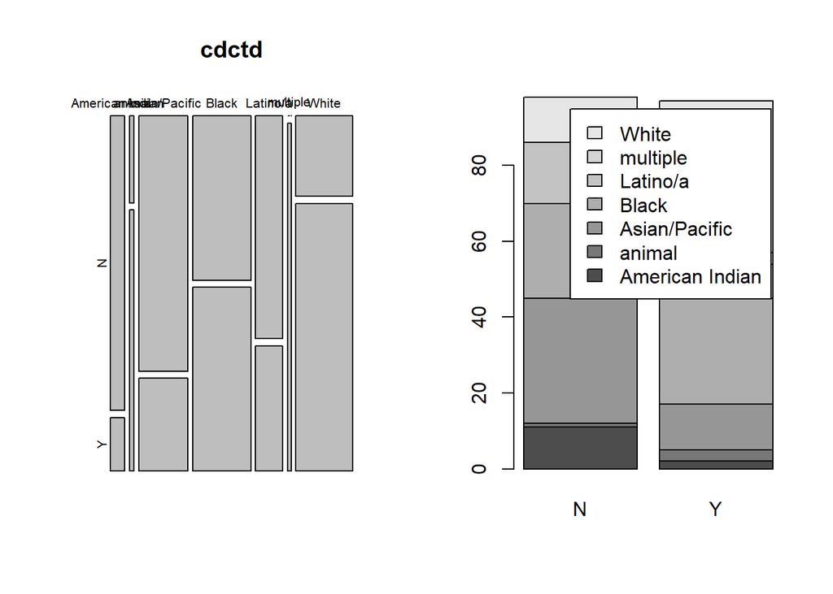

```
##
##  Pearson's Chi-squared test
##
## data:  cdctd
## X-squared = 37.233, df = 6, p-value = 1.586e-06
```

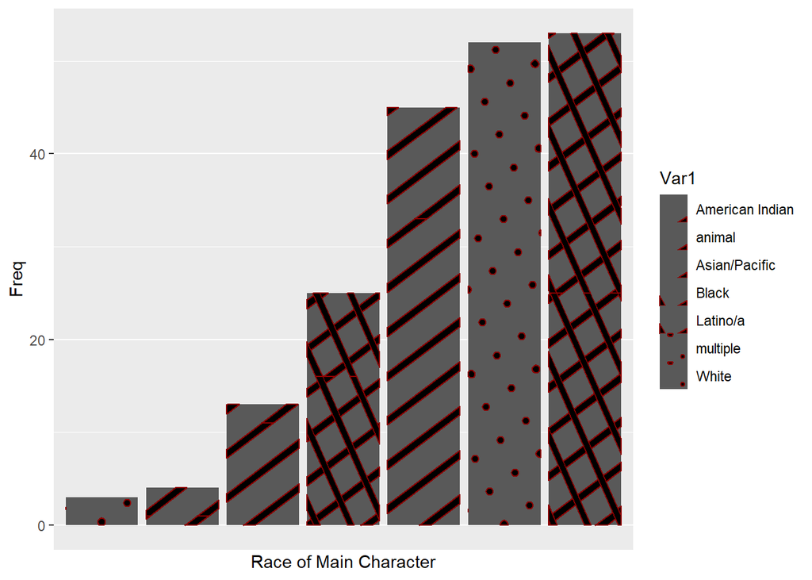

### Branch Library:dig_ctd

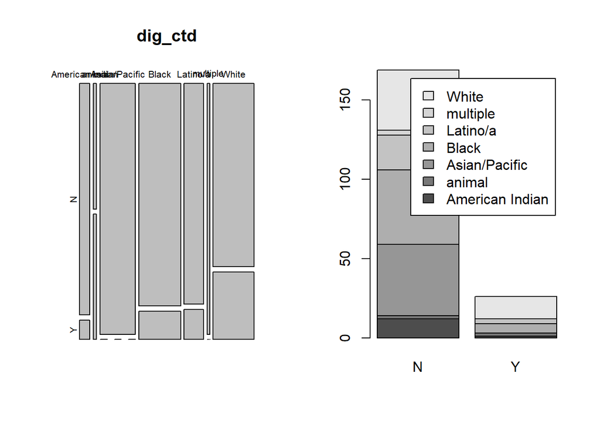

```
##
##  Pearson's Chi-squared test
##
## data:  dig_ctd
## X-squared = 20.931, df = 6, p-value = 0.001887
```

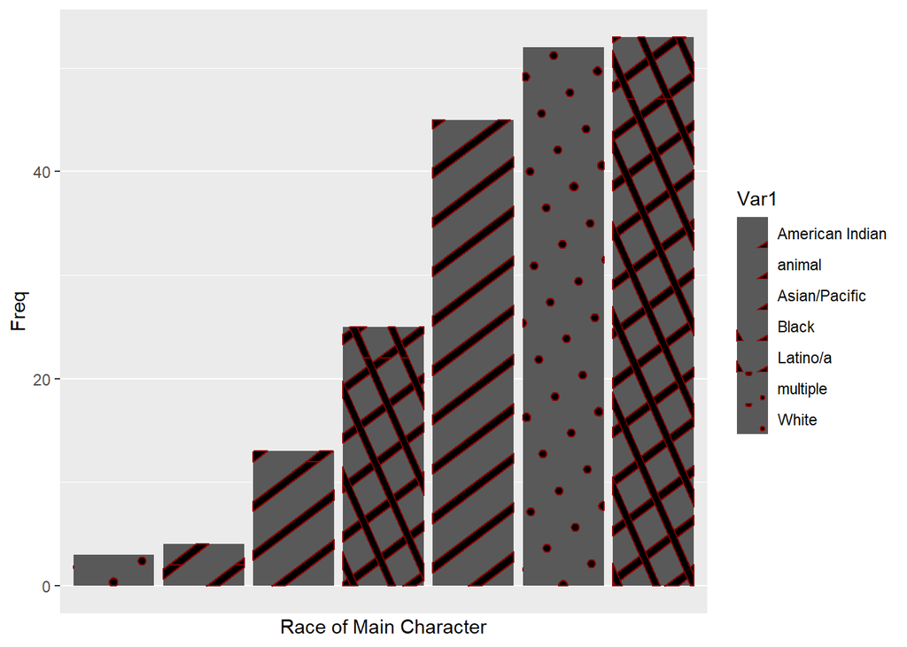

### Branch Library: cdcte

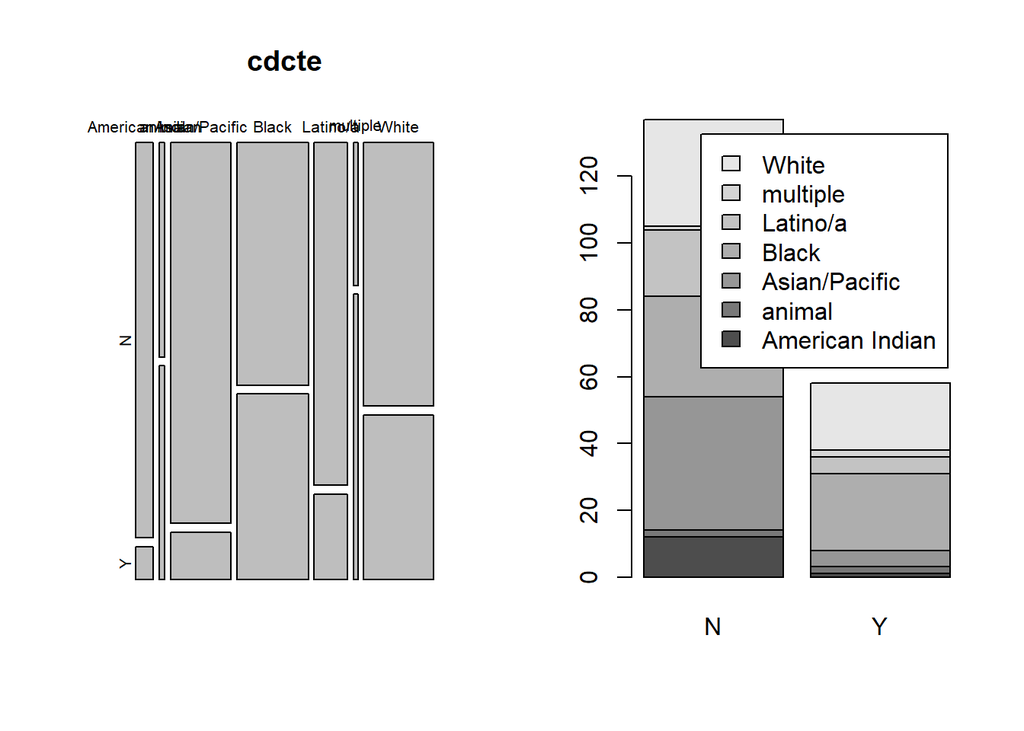

```
##
##  Pearson's Chi-squared test
##
## data:  cdcte
## X-squared = 20.998, df = 6, p-value = 0.001836
```

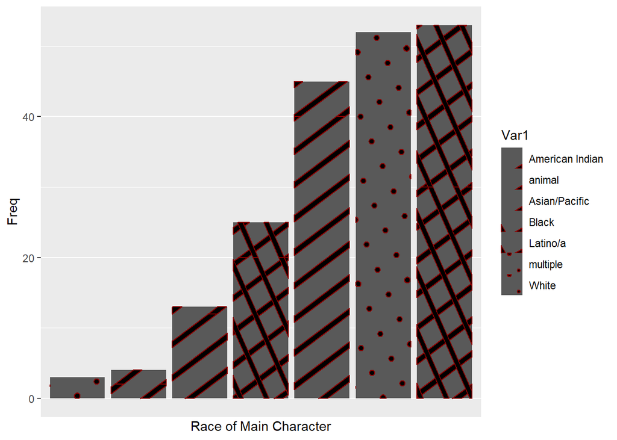

### Branch Library: dig_cte

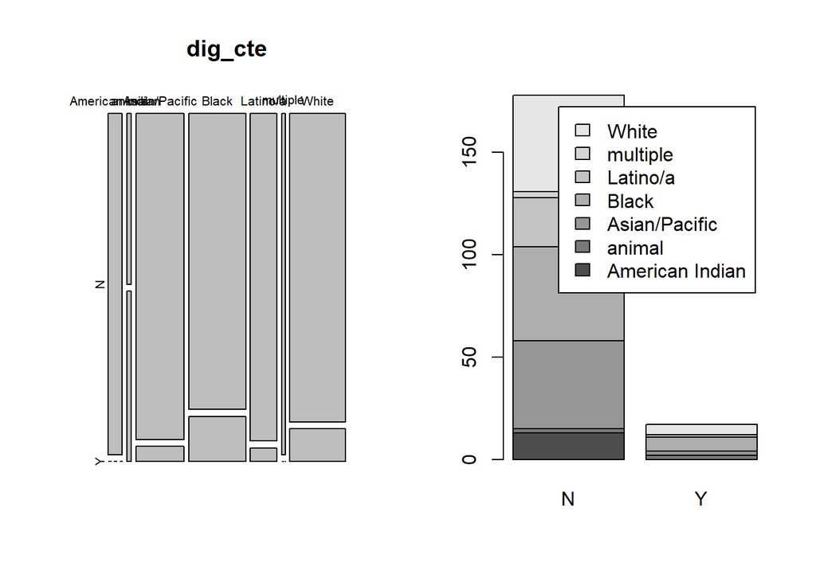

```
##
##  Pearson's Chi-squared test
##
## data:  dig_cte
## X-squared = 13.221, df = 6, p-value = 0.03965
```

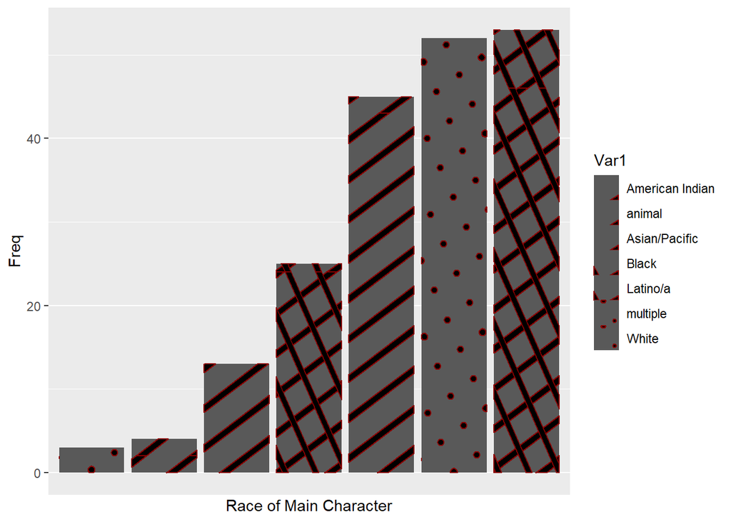

### Branch Library: cdctf

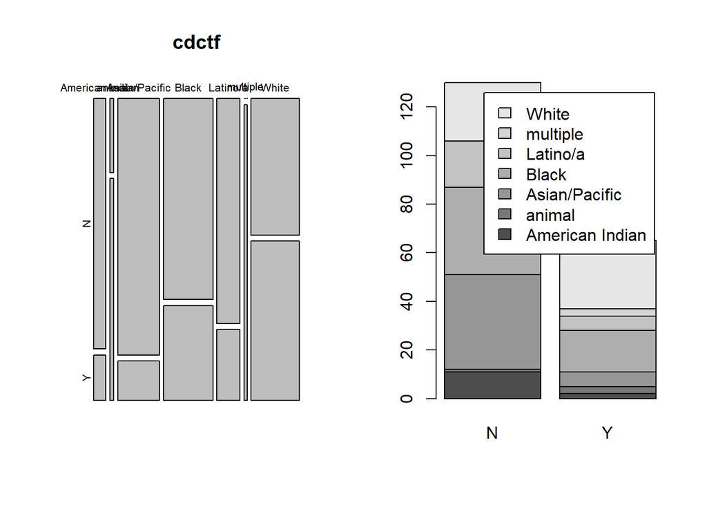

```
##
##  Pearson's Chi-squared test
##
## data:  cdctf
## X-squared = 29.974, df = 6, p-value = 3.977e-05
```

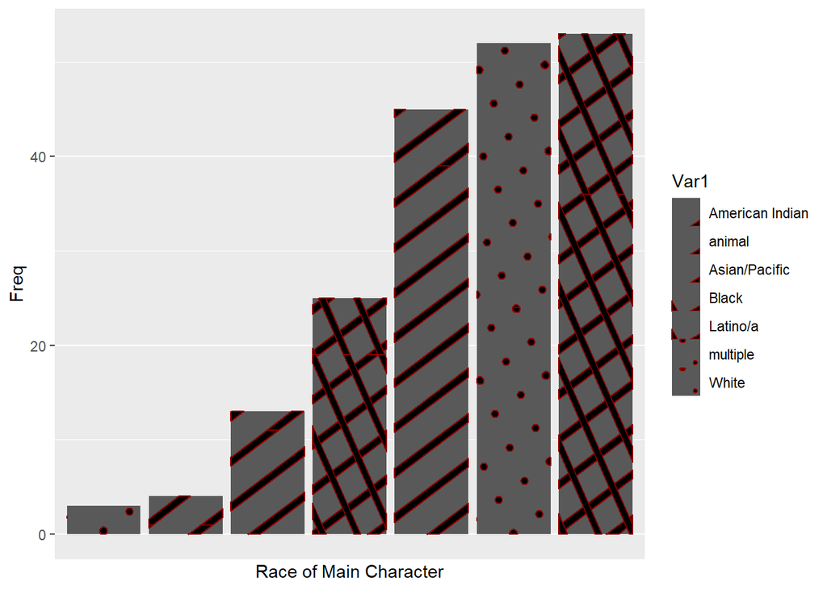

### Branch Library: dig_ctf

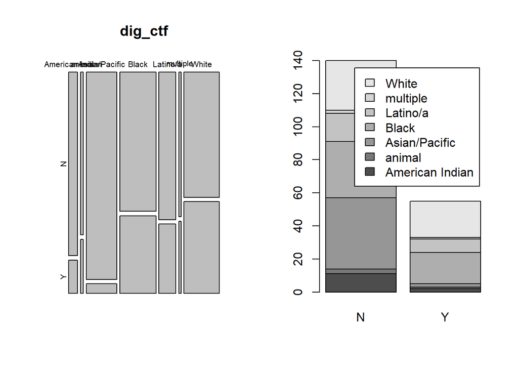

```
##
##  Pearson's Chi-squared test
##
## data:  dig_ctf
## X-squared = 20.475, df = 6, p-value = 0.002279
```

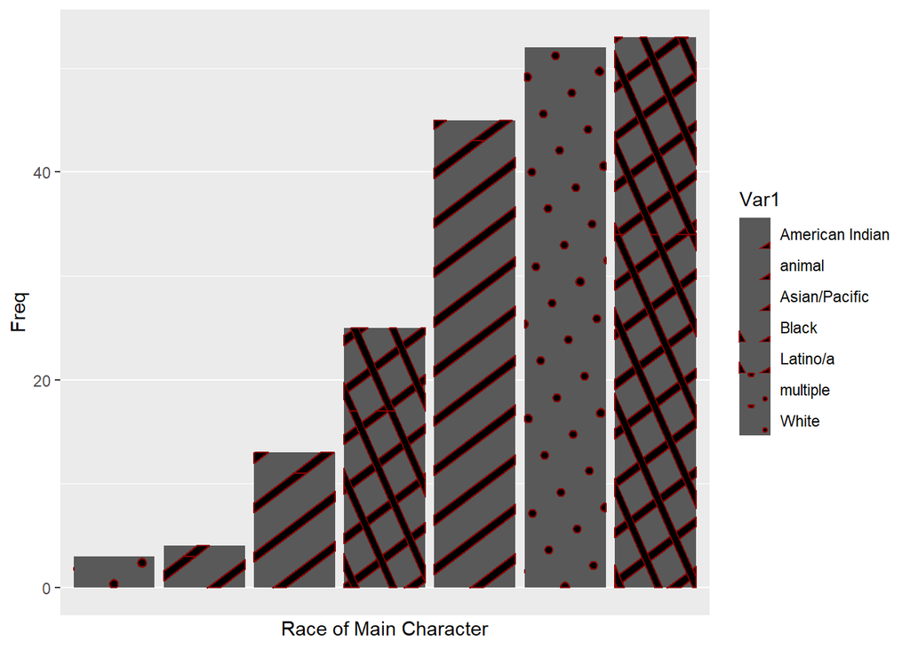